# Risk Factor Analysis

## Outcome Variable

**Outcome Variable:** y_rate_len

## Predictor Variables

**Intervention Variable:** hhwealth_quart

**Adjustment Set:**

unadjusted

## Stratifying Variables

The analysis was stratified on these variable(s):

- agecat
- studyid
- country

## Data Summary

| agecat | studyid | country | hhwealth_quart | n_cell | n |
| --- | --- | --- | --- | --- | --- |
| 0-3 months | COHORTS | GUATEMALA | Wealth Q4 | 248 | 709 |
| 0-3 months | COHORTS | GUATEMALA | Wealth Q1 | 138 | 709 |
| 0-3 months | COHORTS | GUATEMALA | Wealth Q2 | 140 | 709 |
| 0-3 months | COHORTS | GUATEMALA | Wealth Q3 | 183 | 709 |
| 3-6 months | COHORTS | GUATEMALA | Wealth Q4 | 284 | 780 |
| 3-6 months | COHORTS | GUATEMALA | Wealth Q1 | 146 | 780 |
| 3-6 months | COHORTS | GUATEMALA | Wealth Q2 | 156 | 780 |
| 3-6 months | COHORTS | GUATEMALA | Wealth Q3 | 194 | 780 |
| 6-9 months | COHORTS | GUATEMALA | Wealth Q4 | 298 | 799 |
| 6-9 months | COHORTS | GUATEMALA | Wealth Q1 | 156 | 799 |
| 6-9 months | COHORTS | GUATEMALA | Wealth Q2 | 166 | 799 |
| 6-9 months | COHORTS | GUATEMALA | Wealth Q3 | 179 | 799 |
| 9-12 months | COHORTS | GUATEMALA | Wealth Q4 | 335 | 898 |
| 9-12 months | COHORTS | GUATEMALA | Wealth Q1 | 179 | 898 |
| 9-12 months | COHORTS | GUATEMALA | Wealth Q2 | 184 | 898 |
| 9-12 months | COHORTS | GUATEMALA | Wealth Q3 | 200 | 898 |
| 12-15 months | COHORTS | GUATEMALA | Wealth Q4 | 329 | 855 |
| 12-15 months | COHORTS | GUATEMALA | Wealth Q1 | 161 | 855 |
| 12-15 months | COHORTS | GUATEMALA | Wealth Q2 | 184 | 855 |
| 12-15 months | COHORTS | GUATEMALA | Wealth Q3 | 181 | 855 |
| 15-18 months | COHORTS | GUATEMALA | Wealth Q4 | 291 | 772 |
| 15-18 months | COHORTS | GUATEMALA | Wealth Q1 | 146 | 772 |
| 15-18 months | COHORTS | GUATEMALA | Wealth Q2 | 169 | 772 |
| 15-18 months | COHORTS | GUATEMALA | Wealth Q3 | 166 | 772 |
| 18-21 months | COHORTS | GUATEMALA | Wealth Q4 | 281 | 765 |
| 18-21 months | COHORTS | GUATEMALA | Wealth Q1 | 149 | 765 |
| 18-21 months | COHORTS | GUATEMALA | Wealth Q2 | 162 | 765 |
| 18-21 months | COHORTS | GUATEMALA | Wealth Q3 | 173 | 765 |
| 21-24 months | COHORTS | GUATEMALA | Wealth Q4 | 312 | 843 |
| 21-24 months | COHORTS | GUATEMALA | Wealth Q1 | 166 | 843 |
| 21-24 months | COHORTS | GUATEMALA | Wealth Q2 | 177 | 843 |
| 21-24 months | COHORTS | GUATEMALA | Wealth Q3 | 188 | 843 |

The following strata were considered:

- agecat: 0-3 months, studyid: COHORTS, country: GUATEMALA
- agecat: 12-15 months, studyid: COHORTS, country: GUATEMALA
- agecat: 15-18 months, studyid: COHORTS, country: GUATEMALA
- agecat: 18-21 months, studyid: COHORTS, country: GUATEMALA
- agecat: 21-24 months, studyid: COHORTS, country: GUATEMALA
- agecat: 3-6 months, studyid: COHORTS, country: GUATEMALA
- agecat: 6-9 months, studyid: COHORTS, country: GUATEMALA
- agecat: 9-12 months, studyid: COHORTS, country: GUATEMALA

## Methods Detail

We’re interested in the causal parameters $E[Y_a]$ for all values of $a \in \mathcal{A}$. These parameters represent the mean outcome if, possibly contrary to fact, we intervened to set all units to have $A=a$. Under the randomization and positivity assumptions, these are identified by the statistical parameters $\psi_a=E_W[E_{Y|A,W}(Y|A=a,W)]$. In addition, we’re interested in the mean of $Y$, $E[Y]$ under no intervention (the observed mean). We will estimate these parameters by using SuperLearner to fit the relevant likelihood factors – $E_{Y|A,W}(Y|A=a,W)$ and $p(A=a|W)$, and then updating our likelihood fit using a joint TMLE.

For unadjusted analyses ($W=\{\}$), initial likelihoods were estimated using Lrnr_glm to estimate the simple $E(Y|A)$ and Lrnr_mean to estimate $p(A)$. For adjusted analyses, a small library containing Lrnr_glmnet, Lrnr_xgboost, and Lrnr_mean was used.

Having estimated these parameters, we will then use the delta method to estimate relative risks and attributable risks relative to a prespecified baseline level of $A$.

# Results Detail

## Results Plots

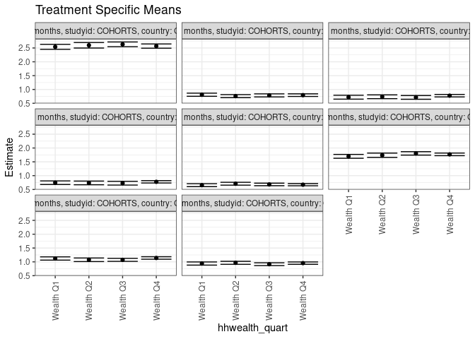

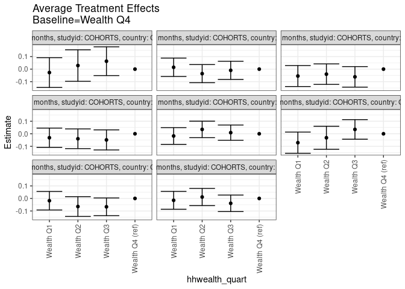

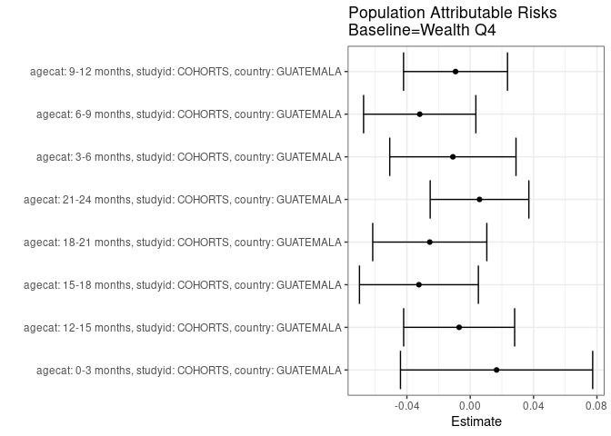

## Results Table

### Parameter: TSM

| agecat | studyid | country | intervention_level | baseline_level | estimate | ci_lower | ci_upper |
| --- | --- | --- | --- | --- | --- | --- | --- |
| 0-3 months | COHORTS | GUATEMALA | Wealth Q4 | NA | 2.5690956 | 2.4921390 | 2.6460523 |
| 0-3 months | COHORTS | GUATEMALA | Wealth Q1 | NA | 2.5418666 | 2.4515494 | 2.6321837 |
| 0-3 months | COHORTS | GUATEMALA | Wealth Q2 | NA | 2.5976975 | 2.4983679 | 2.6970272 |
| 0-3 months | COHORTS | GUATEMALA | Wealth Q3 | NA | 2.6322313 | 2.5472496 | 2.7172129 |
| 3-6 months | COHORTS | GUATEMALA | Wealth Q4 | NA | 1.7700897 | 1.7219883 | 1.8181912 |
| 3-6 months | COHORTS | GUATEMALA | Wealth Q1 | NA | 1.6990880 | 1.6295428 | 1.7686332 |
| 3-6 months | COHORTS | GUATEMALA | Wealth Q2 | NA | 1.7384546 | 1.6602018 | 1.8167073 |
| 3-6 months | COHORTS | GUATEMALA | Wealth Q3 | NA | 1.8048842 | 1.7434681 | 1.8663004 |
| 6-9 months | COHORTS | GUATEMALA | Wealth Q4 | NA | 1.1397837 | 1.0949113 | 1.1846561 |
| 6-9 months | COHORTS | GUATEMALA | Wealth Q1 | NA | 1.1216866 | 1.0629444 | 1.1804287 |
| 6-9 months | COHORTS | GUATEMALA | Wealth Q2 | NA | 1.0751978 | 1.0106402 | 1.1397553 |
| 6-9 months | COHORTS | GUATEMALA | Wealth Q3 | NA | 1.0730582 | 1.0184504 | 1.1276661 |
| 9-12 months | COHORTS | GUATEMALA | Wealth Q4 | NA | 0.9542476 | 0.9121685 | 0.9963268 |
| 9-12 months | COHORTS | GUATEMALA | Wealth Q1 | NA | 0.9393885 | 0.8818685 | 0.9969085 |
| 9-12 months | COHORTS | GUATEMALA | Wealth Q2 | NA | 0.9656514 | 0.9117312 | 1.0195717 |
| 9-12 months | COHORTS | GUATEMALA | Wealth Q3 | NA | 0.9153808 | 0.8648383 | 0.9659233 |
| 12-15 months | COHORTS | GUATEMALA | Wealth Q4 | NA | 0.7943717 | 0.7473271 | 0.8414164 |
| 12-15 months | COHORTS | GUATEMALA | Wealth Q1 | NA | 0.8090742 | 0.7526846 | 0.8654639 |
| 12-15 months | COHORTS | GUATEMALA | Wealth Q2 | NA | 0.7584100 | 0.7034534 | 0.8133666 |
| 12-15 months | COHORTS | GUATEMALA | Wealth Q3 | NA | 0.7847853 | 0.7295389 | 0.8400316 |
| 15-18 months | COHORTS | GUATEMALA | Wealth Q4 | NA | 0.7754793 | 0.7303343 | 0.8206242 |
| 15-18 months | COHORTS | GUATEMALA | Wealth Q1 | NA | 0.7205624 | 0.6500678 | 0.7910570 |
| 15-18 months | COHORTS | GUATEMALA | Wealth Q2 | NA | 0.7354715 | 0.6673150 | 0.8036281 |
| 15-18 months | COHORTS | GUATEMALA | Wealth Q3 | NA | 0.7138094 | 0.6456132 | 0.7820055 |
| 18-21 months | COHORTS | GUATEMALA | Wealth Q4 | NA | 0.7767399 | 0.7347591 | 0.8187206 |
| 18-21 months | COHORTS | GUATEMALA | Wealth Q1 | NA | 0.7453362 | 0.6811059 | 0.8095666 |
| 18-21 months | COHORTS | GUATEMALA | Wealth Q2 | NA | 0.7370573 | 0.6706968 | 0.8034179 |
| 18-21 months | COHORTS | GUATEMALA | Wealth Q3 | NA | 0.7279405 | 0.6599038 | 0.7959773 |
| 21-24 months | COHORTS | GUATEMALA | Wealth Q4 | NA | 0.6735350 | 0.6335418 | 0.7135281 |
| 21-24 months | COHORTS | GUATEMALA | Wealth Q1 | NA | 0.6559060 | 0.6024076 | 0.7094045 |
| 21-24 months | COHORTS | GUATEMALA | Wealth Q2 | NA | 0.7084626 | 0.6564943 | 0.7604309 |
| 21-24 months | COHORTS | GUATEMALA | Wealth Q3 | NA | 0.6825201 | 0.6366281 | 0.7284121 |

### Parameter: E(Y)

| agecat | studyid | country | intervention_level | baseline_level | estimate | ci_lower | ci_upper |
| --- | --- | --- | --- | --- | --- | --- | --- |
| 0-3 months | COHORTS | GUATEMALA | NA | NA | 2.5857395 | 2.5420908 | 2.6293882 |
| 3-6 months | COHORTS | GUATEMALA | NA | NA | 1.7591266 | 1.7281267 | 1.7901266 |
| 6-9 months | COHORTS | GUATEMALA | NA | NA | 1.1078835 | 1.0805783 | 1.1351886 |
| 9-12 months | COHORTS | GUATEMALA | NA | NA | 0.9449661 | 0.9199056 | 0.9700266 |
| 12-15 months | COHORTS | GUATEMALA | NA | NA | 0.7873717 | 0.7605685 | 0.8141750 |
| 15-18 months | COHORTS | GUATEMALA | NA | NA | 0.7430746 | 0.7129350 | 0.7732142 |
| 18-21 months | COHORTS | GUATEMALA | NA | NA | 0.7511843 | 0.7223646 | 0.7800040 |
| 21-24 months | COHORTS | GUATEMALA | NA | NA | 0.6794009 | 0.6558371 | 0.7029647 |

### Parameter: ATE

| agecat | studyid | country | intervention_level | baseline_level | estimate | ci_lower | ci_upper |
| --- | --- | --- | --- | --- | --- | --- | --- |
| 0-3 months | COHORTS | GUATEMALA | Wealth Q4 | Wealth Q4 | 0.0000000 | 0.0000000 | 0.0000000 |
| 0-3 months | COHORTS | GUATEMALA | Wealth Q1 | Wealth Q4 | -0.0272291 | -0.1458862 | 0.0914281 |
| 0-3 months | COHORTS | GUATEMALA | Wealth Q2 | Wealth Q4 | 0.0286019 | -0.0970512 | 0.1542550 |
| 0-3 months | COHORTS | GUATEMALA | Wealth Q3 | Wealth Q4 | 0.0631356 | -0.0515125 | 0.1777838 |
| 3-6 months | COHORTS | GUATEMALA | Wealth Q4 | Wealth Q4 | 0.0000000 | 0.0000000 | 0.0000000 |
| 3-6 months | COHORTS | GUATEMALA | Wealth Q1 | Wealth Q4 | -0.0710017 | -0.1555611 | 0.0135576 |
| 3-6 months | COHORTS | GUATEMALA | Wealth Q2 | Wealth Q4 | -0.0316352 | -0.1234896 | 0.0602193 |
| 3-6 months | COHORTS | GUATEMALA | Wealth Q3 | Wealth Q4 | 0.0347945 | -0.0432164 | 0.1128053 |
| 6-9 months | COHORTS | GUATEMALA | Wealth Q4 | Wealth Q4 | 0.0000000 | 0.0000000 | 0.0000000 |
| 6-9 months | COHORTS | GUATEMALA | Wealth Q1 | Wealth Q4 | -0.0180972 | -0.0920172 | 0.0558229 |
| 6-9 months | COHORTS | GUATEMALA | Wealth Q2 | Wealth Q4 | -0.0645859 | -0.1432066 | 0.0140347 |
| 6-9 months | COHORTS | GUATEMALA | Wealth Q3 | Wealth Q4 | -0.0667255 | -0.1374047 | 0.0039537 |
| 9-12 months | COHORTS | GUATEMALA | Wealth Q4 | Wealth Q4 | 0.0000000 | 0.0000000 | 0.0000000 |
| 9-12 months | COHORTS | GUATEMALA | Wealth Q1 | Wealth Q4 | -0.0148591 | -0.0861276 | 0.0564094 |
| 9-12 months | COHORTS | GUATEMALA | Wealth Q2 | Wealth Q4 | 0.0114038 | -0.0569925 | 0.0798001 |
| 9-12 months | COHORTS | GUATEMALA | Wealth Q3 | Wealth Q4 | -0.0388668 | -0.1046330 | 0.0268995 |
| 12-15 months | COHORTS | GUATEMALA | Wealth Q4 | Wealth Q4 | 0.0000000 | 0.0000000 | 0.0000000 |
| 12-15 months | COHORTS | GUATEMALA | Wealth Q1 | Wealth Q4 | 0.0147025 | -0.0587345 | 0.0881395 |
| 12-15 months | COHORTS | GUATEMALA | Wealth Q2 | Wealth Q4 | -0.0359618 | -0.1083042 | 0.0363807 |
| 12-15 months | COHORTS | GUATEMALA | Wealth Q3 | Wealth Q4 | -0.0095865 | -0.0821493 | 0.0629764 |
| 15-18 months | COHORTS | GUATEMALA | Wealth Q4 | Wealth Q4 | 0.0000000 | 0.0000000 | 0.0000000 |
| 15-18 months | COHORTS | GUATEMALA | Wealth Q1 | Wealth Q4 | -0.0549169 | -0.1386281 | 0.0287943 |
| 15-18 months | COHORTS | GUATEMALA | Wealth Q2 | Wealth Q4 | -0.0400077 | -0.1217597 | 0.0417443 |
| 15-18 months | COHORTS | GUATEMALA | Wealth Q3 | Wealth Q4 | -0.0616699 | -0.1434549 | 0.0201151 |
| 18-21 months | COHORTS | GUATEMALA | Wealth Q4 | Wealth Q4 | 0.0000000 | 0.0000000 | 0.0000000 |
| 18-21 months | COHORTS | GUATEMALA | Wealth Q1 | Wealth Q4 | -0.0314036 | -0.1081364 | 0.0453291 |
| 18-21 months | COHORTS | GUATEMALA | Wealth Q2 | Wealth Q4 | -0.0396825 | -0.1182071 | 0.0388420 |
| 18-21 months | COHORTS | GUATEMALA | Wealth Q3 | Wealth Q4 | -0.0487993 | -0.1287454 | 0.0311468 |
| 21-24 months | COHORTS | GUATEMALA | Wealth Q4 | Wealth Q4 | 0.0000000 | 0.0000000 | 0.0000000 |
| 21-24 months | COHORTS | GUATEMALA | Wealth Q1 | Wealth Q4 | -0.0176289 | -0.0844237 | 0.0491658 |
| 21-24 months | COHORTS | GUATEMALA | Wealth Q2 | Wealth Q4 | 0.0349276 | -0.0306480 | 0.1005033 |
| 21-24 months | COHORTS | GUATEMALA | Wealth Q3 | Wealth Q4 | 0.0089851 | -0.0518880 | 0.0698582 |

### Parameter: PAR

| agecat | studyid | country | intervention_level | baseline_level | estimate | ci_lower | ci_upper |
| --- | --- | --- | --- | --- | --- | --- | --- |
| 0-3 months | COHORTS | GUATEMALA | Wealth Q4 | NA | 0.0166438 | -0.0440555 | 0.0773432 |
| 3-6 months | COHORTS | GUATEMALA | Wealth Q4 | NA | -0.0109631 | -0.0508361 | 0.0289100 |
| 6-9 months | COHORTS | GUATEMALA | Wealth Q4 | NA | -0.0319002 | -0.0673565 | 0.0035560 |
| 9-12 months | COHORTS | GUATEMALA | Wealth Q4 | NA | -0.0092816 | -0.0421083 | 0.0235452 |
| 12-15 months | COHORTS | GUATEMALA | Wealth Q4 | NA | -0.0070000 | -0.0420480 | 0.0280479 |
| 15-18 months | COHORTS | GUATEMALA | Wealth Q4 | NA | -0.0324046 | -0.0699545 | 0.0051452 |
| 18-21 months | COHORTS | GUATEMALA | Wealth Q4 | NA | -0.0255555 | -0.0615866 | 0.0104755 |
| 21-24 months | COHORTS | GUATEMALA | Wealth Q4 | NA | 0.0058659 | -0.0252912 | 0.0370231 |